# Effective Sample Sizes

Continuous-Time Movement Modeling

Christen H. Fleming and Erika Y. Lin

2026-08-26

*Created: 2026-06-30* | *Last updated: 2026-08-26*

## 1 Learning Objectives

By the end of this module you will be able to:

1. Understand the effective and absolute sample sizes and distinguish between them.
2. Perform parametric bootstrapping to improve parameter estimates and confidence intervals.

**Packages used:** `ctmm`

## 2 Background

When working with our data, it is important to distinguish between the **absolute sample size** ($n$) and **effective sample size** (ESS; $N_{ESS}$). If small sample sizes are not accounted for, our results from home-range and speed estimation can be heavily biased.

> What is an **absolute sample size**?

> *Answer:* In terms of telemetry data, this is the total number of tracked locations.

> The absolute sample size is the product of the sampling duration (how long the animal was tracked for) and the sampling frequency (how often locations were recorded). This is can be calculated as:
> $$n=\frac{\text{sampling duration}}{\text{sampling
> interval}}=\frac{T}{\Delta t}$$

> What is an **effective sample size**?

> *Answer:* This is the number of independent locations that would produce the same quality home range (or speed) estimate as the absolute sample size. This is also known as the “degrees of freedom” (DOF).

> In other words, this represents the amount of actual information content present in our data. Because the ESS relates to the different autocorrelation timescales (i.e., position autocorrelation, $\tau_p$, and velocity autocorrelation, $\tau_v$), the ESS is different for home range estimation ($N_{\text{area}}$) and speed estimation ($N_{\text{speed}}$). The home-range area ESS can be roughly estimated as:
> $$N_{\text{area}}\approx\frac{\text{sampling
> duration}}{\text{average home range crossing time, position
> autocorrelation}}\approx\frac{T}{\tau_p}$$

For independent data, the ESS is the same as the absolute sample size ($n=N_{ESS}$), however, if the data is autocorrelated, each new data point does not give completely new and independent information, so ESS is less than the absolute sample size ($n>N_{ESS}$. In the case of range resident animals, the ESS often is much smaller than the amount of data we collect, especially for home-range estimation ($n\gg N_{ESS}$).

For example, consider the standard error of the IID mean estimate from Statistics 101:
$$S.E. =
\frac{S.D.}{\sqrt{n}}$$
where,

S.E. = the standard error (uncertainty) of the mean estimate  
S.D. = the standard deviation of the process itself  
n = the nominal (or absolute) sample size (the actual number of data points)

With larger ‘$n$’, the standard error (uncertainty) is smaller, but with autocorrelated data, this exact relationship does not hold. Given S.E., we can invert the relationship with the effective sample size,
$$S.E. = \frac{S.D.}{\sqrt{N_{ESS}}}$$
to get ‘$N_{ESS}$’ as the “effective sample size”
$$N_{ESS} =
\frac{S.D.^2}{S.E.^2}$$
which can be used as a relative measure of the certainty. If we had $N_{ESS}$ IID data points, then we would get the same quality estimate as we would with the absolute sample size, $n$.

## 3 Data Preparation

Here, we will use tracking data from GPS-collared Mongolian gazelles (*Procapra gutturosa*). The exact locations of these animals is protected, so we will work only with their time-stamped $(x,y)$ relative locations in kilometers.

### 3.1 Import and Visualize Data

```r
# Load ctmm package
library(ctmm)

# Import gazelle data
data(gazelle)

# Select the 18th gazelle individual
DATA <- gazelle[[18]]

# Summarize the data
summary(DATA)  # longitude and latitude not publicly shared
```

```
## $identity
## [1] "618674A"
##
## $`sampling interval (hours)`
## [1] 1.002778
##
## $`sampling period (months)`
## [1] 12.22181
##
## $`longitude range`
## [1]  Inf -Inf
##
## $`latitude range`
## [1]  Inf -Inf
```

```
## DOP values missing. Assuming DOP=1.
```

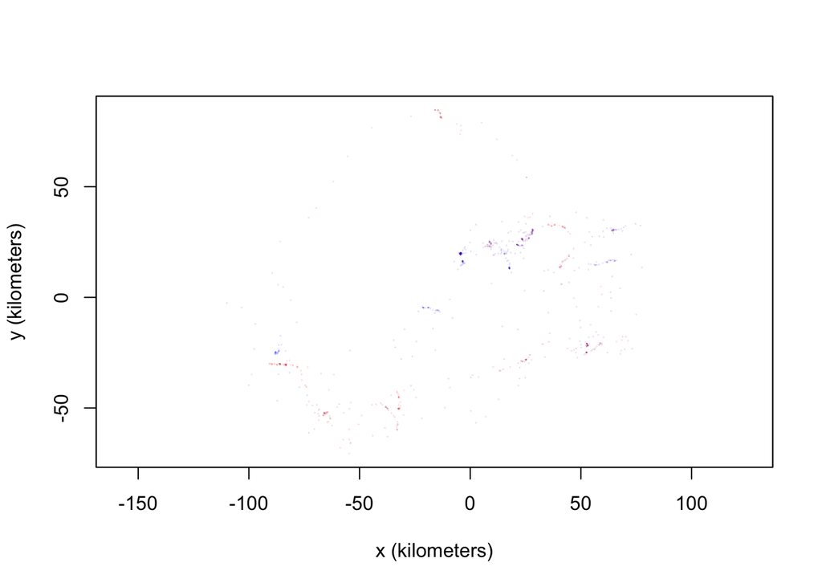

```r
# Let's visualize this individual's tracks
COL <- color(DATA, by = 'time')  # color location points by time
plot(DATA, col = COL)
```

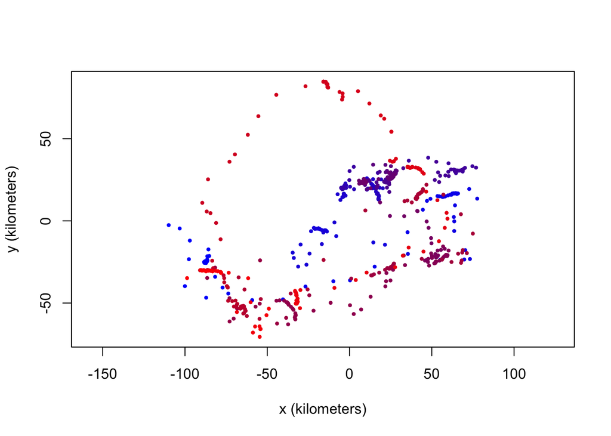

```r
plot(DATA, col = COL, error = FALSE,  # can be hard to see points if error = TRUE
     pch = 16, cex = 0.6)  # solid fill data points
```

Typically Mongolian gazelles exhibit a seasonal nomadic range crossing time with weak site fidelity. This particular individual crosses its range 2-3 times during the study period of ~1 year.

### 3.2 Model Selection

Once again, we will select the continuous-time movement model with the best fit parameters and optimized autocorrelation timescales. And since this may take some time, we have already run this, so the saved results can be loaded. There will be warnings about there being no longitude or latitude values, but this is expected for this data, so we can ignore those warnings.

```r
# Guestimate model parameters
GUESS <- ctmm.guess(DATA, interactive = FALSE)

# Select best model
FIT <- ctmm.select(DATA, GUESS, trace = 3)
save(FIT, file = "data/gazelle.rda")
```

```r
load("data/gazelle.rda")  # load saved model selection results
```

## 4 Effective Sample Size

```r
# Note the sampling period
summary(DATA)[3]  # ~1 year
```

```
## $`sampling period (months)`
## [1] 12.22181
```

```r
# Absolute sample size
nrow(DATA)
```

```
## [1] 866
```

```r
# Summarize model
summary(FIT)  # OUF anisotropic selected
```

```
## $name
## [1] "OUF anisotropic"
##
## $DOF
##       mean       area  diffusion      speed
##   2.063560   2.381675 372.248104 833.339058
##
## $CI
##                                            low          est         high
## area (square kilometers)          9492.3737107 60839.344209 1.588911e+05
## τ[position] (months)                 0.8908573     5.741925 3.700896e+01
## τ[velocity] (hours)                  1.6981748     1.845849 2.006365e+00
## speed (kilometers/day)              21.6725192    22.434206 2.319554e+01
## diffusion (square kilometers/day)   34.7436245    38.561938 4.257645e+01
```

```r
## Note the effective sample sizes (DOF[mean] and DOF[area])
## DOF[mean] = central location ESS
## DOF[area] = size of area ESS
```

Take note of the sampling period and interval of the data. Here, the absolute sample size of location points is 866. However, the ESS for estimating the central location of the individual (DOF[mean]) is ~2.1 and the ESS for the home range area (DOF[area]) is ~2.4 location points. Therefore, there are approximately 2 effective data points for continuous-time estimation, but ~372 (note the DOF[diffusion] for habitat selection with SSFs (*more to come*).

```r
# SI units converter
1 %#% 'hr'  # how many seconds in an hour
```

```
## [1] 3600
```

```r
# Approximate effective sample size
## period of data / HR estimation autocorrelation (should be about the # of HR crossings)
(12.22181 %#% "month") / (5.741925 %#% "month")  # N_area = T / tau_p
```

```
## [1] 2.128521
```

```r
# Compare to estimate
summary(FIT)$DOF
```

```
##       mean       area  diffusion      speed
##   2.063560   2.381675 372.248104 833.339058
```

```r
## high bias (only 2 effective data points)
```

```r
# ctmm.fit/ctmm.select help file
help("ctmm.fit")
## Note the "methods" argument
## Default method is not maximum likelihood (ML),
### need specific minimum effective sample sizes to work properly
```

For a target bias of O(5%), we would need an ESS of at least 2-20, depending on the model fitting method used:

| Function | Method | Required DOF[area] | Notes |
| --- | --- | --- | --- |
| `ctmm.fit` | `method = "ML"` | DOF[area] >= **20** points | (CONVENTIONAL) |
| `ctmm.fit` | `method = "pHREML"` | DOF[area] >= **4-5** points | (DEFAULT) |
| `ctmm.boot` | `method = "pHREML"` | DOF[area] >= **2-3** points | (SLOW) |

…but in all cases DOF[area] is an estimate.

## 5 Bootstrapping

If we have very small effective sample sizes, we can use parametric bootstrapping (`ctmm.boot`) to improve our point estimates and confidence intervals. This process simulates independent “samples” of the data based on parameter estimates from the sampling distribution and can be used to reduce underestimation from other methods like maximum likelihood (ML) and perturbative home range estimation, such as pHREML (Fleming et al., 2019). Because bootstrapping is simulation-based, refitting as many times, as needed to reach the threshold, this process can be much slower and computationally expensive than other methods, so we only recommend using `ctmm.boot` in cases where the ESS is very small.

```r
help("ctmm.boot")

# This will take a long time if running on full data
BOOT <- ctmm.boot(DATA, FIT, cores = -1)
## fitting as many times as needed to reach threshold
```

## 6 Key functions reference

| Function | Package | Purpose |
| --- | --- | --- |
| `ctmm.boot()` | `ctmm` | Perform parametric bootstrapping to improve on point estimates and confidence intervals from an initial estimated movement model (NOTE: computationally expensive) |

*Next: **AKDE, Home Range Meta-Analysis, Population Ranges** — We estimate home ranges using autocorrelated kernel density estimation (AKDE), perform a meta-analysis to compare home ranges across individuals, and estimate population-level range distributions.*